# ROE Levers of Nordic Banks

## MECE

### 1. Identity:

$$ROE = \frac{Net\;
Income}{Equity}.$$

### 2. DuPont Decomposition:

$$ROE = \frac{Net\; Income}{Assets} \times
\frac{Assets}{Equity}.$$

The structural breakdown of ROA is essentially:

$$ROA = \frac{Net\; Interest\; Income +
Net\; Fee\; Income - Operating\; Expenses - Net\; Expected\; Credit\;
Losses - Taxes}{Assets}$$

We do not consider taxes as a part of the core controllable levers a bank can reliably pull, thus we exclude it to arrive at the strategic decomposition of drivers:

$$ROE = \left(\underbrace{\frac{Net\;
Interest\; Income}{Assets}}_{Interest\; Earning\; Intensity} +
\underbrace{\frac{Net\; Fee\; Income}{Assets}}_{Fee\; Income\;
Contribution} - \underbrace{\frac{Operating\; Expenses}{Assets}}_{Cost\;
Efficiency} - \underbrace{\frac{Net\; Expected\; Credit\;
Losses}{Assets}}_{Credit\; Risk\; Discipline}\right) \div
\underbrace{\frac{Equity}{Assets}}_{Capital\; Intensity}.$$

## Data

We collect annual reporting from 2014 to 2025 of three banks, SEB, Nordea, and Handelsbanken, and record data for

- Net profit (attributable to shareholders)
- Net interest income
- Net fee income
- Operating expenses
- Total assets (average)
- Equity (average)
- Net (expected) credit losses

And derive the ratios directly from those underlying accounting figures in order to reserve control over the calculations. This ensures consistency across banks and avoids potential incompatibilities in how headline ratios are reported. We then let the variables be coded as:
$$\begin{aligned}
NII& := \frac{Net\; Interest\; Income}{Assets}, \\
NFI& := \frac{Net\; Fee\; Income}{Assets}, \\
OPX& := \frac{Operating\; Expenses}{Assets}, \\
ECL& := \frac{Net\; Expected\; Credit\; Losses}{Assets}, \\
ETA& := \frac{Equity}{Assets}.
\end{aligned}$$

```r
# Load Raw Layer
df <- read_parquet("data/data.parquet")
df$Bank <- factor(df$Bank)

# Compile Silver Layer
df <- df %>%
  transmute(
    Bank = `Bank`,
    Year = `Year`,
    ROE  = `Net profit` / `Average equity`,
    NII  = `Net interest income` / `Average total assets`,
    NFI  = `Net fee income` / `Average total assets`,
    OPX  = `Operating expenses` / `Average total assets`,
    ECL  = `Loan loss provisions` / `Average total assets`,
    ETA  = `Average equity` / `Average total assets`
  )

varcols = setdiff(colnames(df), c("Bank", "Year"))
Xcols   = setdiff(varcols, c("ROE"))
Ycol    = setdiff(varcols, Xcols)
```

### Inspection

It is a helpful intuition and sanity check for us to visualize the evolution of the data over time to get an idea of the situation. Then we follow up with pairwise inspection. From this we can see clear differences and abnormalities We have double-checked anomalies, e.g. Handelsbanken’s lack of ECL spike in 2020, and confirmed their accuracy.

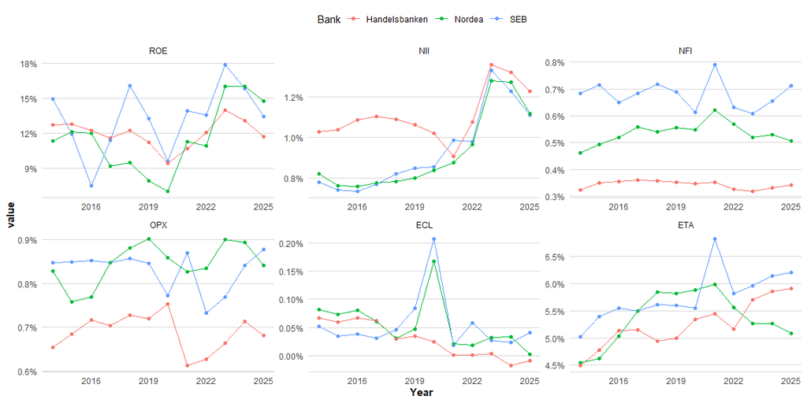

```r
df_long <- pivot_longer(df, varcols, names_to = "variable",values_to = "value") %>%
  mutate(variable = factor(variable, levels = varcols))

ggplot(df_long, aes(Year, value, color = Bank)) +
  geom_point() +
  geom_line() +
  #geom_smooth(method = "lm", se = FALSE) +
  facet_wrap(~variable, scales = "free") +
  scale_y_continuous(labels = percent) +
  theme_line()
```

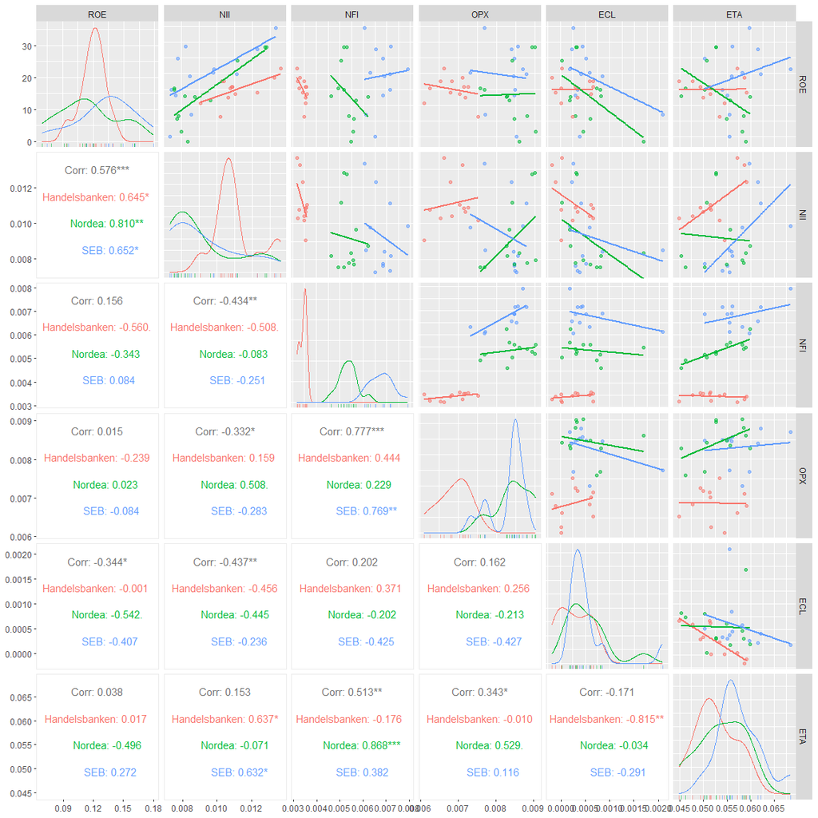

```r
ggpairs(
  df,
  columns=varcols,
  aes(color=Bank, alpha=0.5),
  upper = list(continuous = wrap("smooth", se = FALSE)),
  lower = list(continuous = wrap("cor", size = 4)),
  diag  = list(continuous = diag_density_rug)
)
```

## Model Estimation

We estimate a linear characterization of ROE using the operational drivers derived from the DuPont decomposition. A specification including bank fixed effects is first estimated in order to test whether persistent institution–specific differences are present. The bank indicators are not statistically significant, suggesting that the variation in ROE across the sample is primarily explained by differences in operational structure rather than other bank‑level effects. The pooled specification is therefore used as the main model for interpretation.

The regression results show that all five drivers are statistically significant and jointly explain approximately 83% of the variation in ROE in the sample. Net fee income relative to assets emerges as the strongest differentiator of profitability, followed by net interest income intensity. Cost intensity and credit losses have the expected negative relationship with ROE, while a higher equity ratio reduces ROE through the mechanical effect of lower leverage.

The standardized coefficients provide additional insight into the relative importance of each driver. While the raw coefficients measure the mechanical sensitivity of ROE to a one-percentage-point change in each ratio, the standardized estimates account for the typical variation of each variable in the sample. The results indicate that the revenue drivers are together the most important explanatory factors of ROE, and are closer in importance to each other when their movability is taken into account. In contrast, cost intensity, credit losses, and capital intensity play smaller comparable roles in explaining differences in ROE across the sample. This suggests that variation in revenue generation, with particular emphasis on the scale of fee-generating activities, is the primary differentiator of ROE among Nordic banks in the recent environment.

Diagnostic tests indicate that the model performs well given the limited sample size. The residual plots show mild departures from normality, primarily driven by a small number of outlying observations, but there is no clear pattern suggesting functional misspecification. The Breusch–Pagan test does not indicate heteroskedasticity, and variance inflation factors remain low, suggesting that multicollinearity among the drivers is limited. Overall, the diagnostic profile supports the validity of the specification for exploratory inference.

```r
df[varcols] <- df[varcols] * 100

m <- lm(
  ROE ~ NII + NFI + OPX + ECL + ETA + Bank,
  data = df
)
print(summary(m))
```

```
Call:
lm(formula = ROE ~ NII + NFI + OPX + ECL + ETA + Bank, data = df)

Residuals:
     Min       1Q   Median       3Q      Max
-2.67253 -0.51860 -0.00934  0.51534  2.97387

Coefficients:
            Estimate Std. Error t value Pr(>|t|)
(Intercept)  16.3057     3.6393   4.480 0.000115 ***
NII          14.2562     1.4749   9.666 2.03e-10 ***
NFI          31.1308     7.6177   4.087 0.000333 ***
OPX         -16.6316     5.1639  -3.221 0.003231 **
ECL         -10.7983     5.2106  -2.072 0.047552 *
ETA          -3.6431     0.5631  -6.469 5.23e-07 ***
BankNordea   -0.3761     1.2614  -0.298 0.767813
BankSEB      -2.0209     2.1000  -0.962 0.344108
---
Signif. codes:  0 ‘***’ 0.001 ‘**’ 0.01 ‘*’ 0.05 ‘.’ 0.1 ‘ ’ 1

Residual standard error: 1.116 on 28 degrees of freedom
Multiple R-squared:  0.8429,    Adjusted R-squared:  0.8037
F-statistic: 21.47 on 7 and 28 DF,  p-value: 1.107e-09
```

```r
m <- lm(
  ROE ~ NII + NFI + OPX + ECL + ETA,
  data = df
)
s <- summary(m)
print(s)
```

```
Call:
lm(formula = ROE ~ NII + NFI + OPX + ECL + ETA, data = df)

Residuals:
    Min      1Q  Median      3Q     Max
-3.3945 -0.4454 -0.0145  0.4515  2.9011

Coefficients:
            Estimate Std. Error t value Pr(>|t|)
(Intercept)  15.6999     3.2128   4.887 3.21e-05 ***
NII          13.2232     1.2986  10.183 3.00e-11 ***
NFI          22.4060     2.6434   8.476 1.85e-09 ***
OPX         -11.2802     3.6164  -3.119  0.00398 **
ECL         -12.3341     4.9062  -2.514  0.01754 *
ETA          -3.4211     0.5133  -6.664 2.21e-07 ***
---
Signif. codes:  0 ‘***’ 0.001 ‘**’ 0.01 ‘*’ 0.05 ‘.’ 0.1 ‘ ’ 1

Residual standard error: 1.124 on 30 degrees of freedom
Multiple R-squared:  0.8294,    Adjusted R-squared:  0.801
F-statistic: 29.17 on 5 and 30 DF,  p-value: 1.146e-10
```

```r
lm.beta(m)
```

```
Call:
lm(formula = ROE ~ NII + NFI + OPX + ECL + ETA, data = df)

Standardized Coefficients::
(Intercept)         NII         NFI         OPX         ECL         ETA
         NA   1.0202476   1.2861017  -0.3769127  -0.2138195  -0.6844376
```

```
=================== Diagnostics ===================

    Shapiro-Wilk normality test

data:  resid(model)
W = 0.93807, p-value = 0.04427


    studentized Breusch-Pagan test

data:  model
BP = 8.0689, df = 5, p-value = 0.1525


    Durbin-Watson test

data:  model
DW = 2.0632, p-value = 0.5196
alternative hypothesis: true autocorrelation is greater than 0


    RESET test

data:  model
RESET = 0.65833, df1 = 2, df2 = 28, p-value = 0.5255

        VIF

     NII      NFI      OPX      ECL      ETA
1.765264 4.048081 2.567558 1.272001 1.854662


Influence measures of
     lm(formula = ROE ~ NII + NFI + OPX + ECL + ETA, data = df) :

      dfb.1_  dfb.NII  dfb.NFI  dfb.OPX   dfb.ECL  dfb.ETA   dffit cov.r   cook.d    hat inf
1   0.237967  0.00768  0.27303 -0.08623 -0.115274 -0.30161  0.4250 1.227 3.02e-02 0.1678
2   0.029991 -0.01321 -0.02793  0.05974  0.015084 -0.07292  0.1355 1.453 3.16e-03 0.1716
3  -0.063077 -0.01766 -0.01955  0.03699 -0.015829  0.05125 -0.0899 1.477 1.39e-03 0.1766
4  -0.210872  0.11088 -0.24542  0.11241  0.197498  0.16874 -0.4327 1.161 3.11e-02 0.1497
```

[output cut: 17 more lines]

```
22 -0.200127 -0.03450  0.12602 -0.10135 -0.074914  0.30445  0.5528 1.396 5.12e-02 0.2628
23 -0.006752 -0.02515 -0.00427  0.00013 -0.019576  0.02450  0.0477 1.345 3.92e-04 0.0933
24  0.203346 -0.20703 -0.01871 -0.21743 -0.139048  0.11100  0.3805 1.536 2.46e-02 0.2652
25 -0.049174 -0.02156 -0.09293  0.11029 -0.018445 -0.00253 -0.1338 1.440 3.08e-03 0.1649
26  0.035296  0.05621  0.02245 -0.11976  0.186862  0.01302 -0.3441 0.852 1.90e-02 0.0534
27 -0.117804  0.02759 -0.01900  0.10880  0.068448  0.01054 -0.1832 1.400 5.75e-03 0.1565
28 -0.015236  0.17354  0.13946 -0.09238  0.023833 -0.03303  0.2228 1.537 8.51e-03 0.2294
29 -0.088354  0.12933 -0.01644  0.12677  0.009853 -0.07512  0.2027 1.657 7.06e-03 0.2766   *
30 -0.010339  0.03268 -0.01212 -0.02016  0.000506  0.02567  0.0887 1.467 1.36e-03 0.1710
31 -0.006257  0.01002  0.00629 -0.00108  0.000392  0.00102  0.0155 1.441 4.15e-05 0.1500
32 -0.032540  0.05404 -0.00158  0.04659  0.004119 -0.03254  0.0806 1.642 1.12e-03 0.2563   *
33 -0.059667  0.02263 -0.07479  0.02233 -0.036943  0.07943  0.1711 1.453 5.02e-03 0.1795
34  0.238872 -0.23252 -0.17087 -0.01535 -0.053270 -0.07849 -0.4819 1.056 3.81e-02 0.1367
35 -0.000638 -0.01810 -0.00381 -0.02064  0.021149  0.02875 -0.0485 1.433 4.05e-04 0.1470
36  0.007860  0.00408  0.01793  0.00655  0.010396 -0.02846 -0.0488 1.475 4.11e-04 0.1710
```

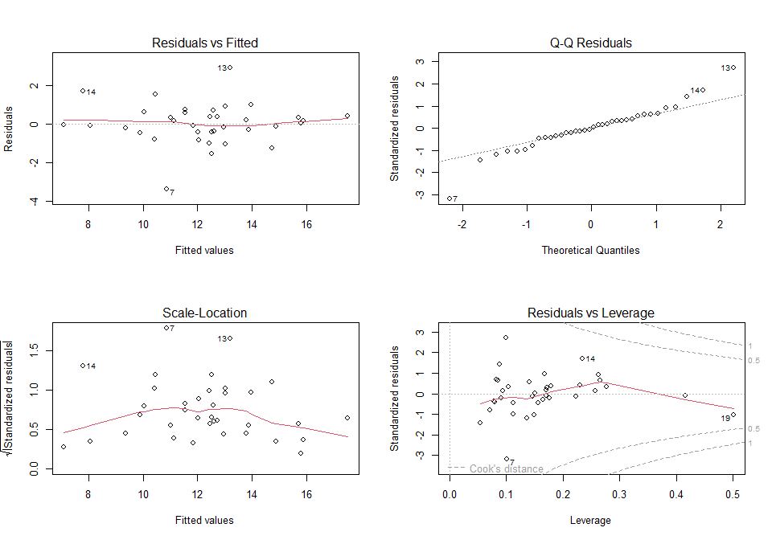

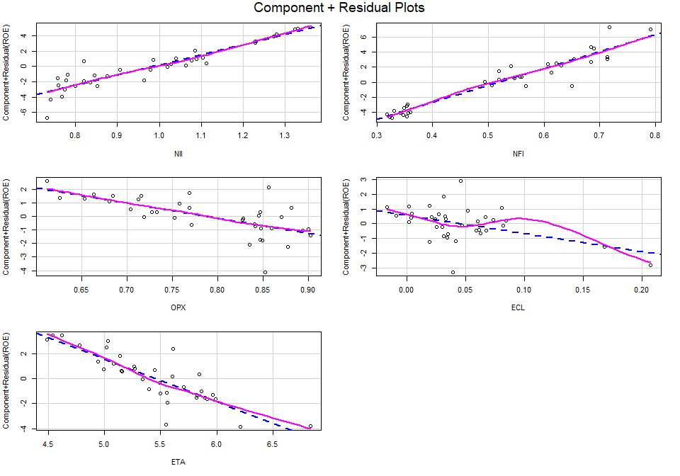

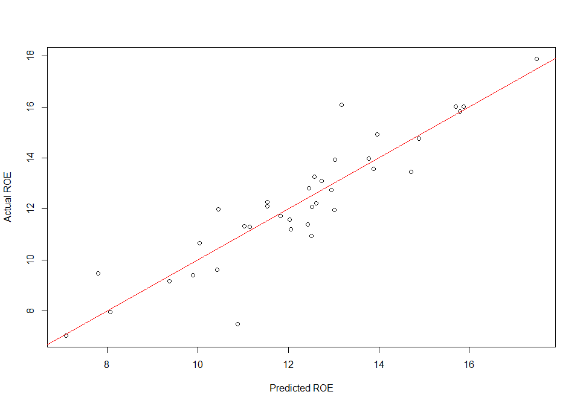

```r
diagnostics(m)
```

## Conclusion

The results highlight that differences in Nordic bank profitability are driven more by revenue generation than by cost drag, credit risk discipline, or leverage. In particular, fee‑generating activities appear to be a key lever for improving ROE, plausibly as they contribute to profitability without requiring proportional balance‑sheet expansion. The analysis suggests that Nordic banks seeking to improve ROE may therefore benefit more from expanding fee-generating activities than from further balance-sheet expansion or cost compression alone.

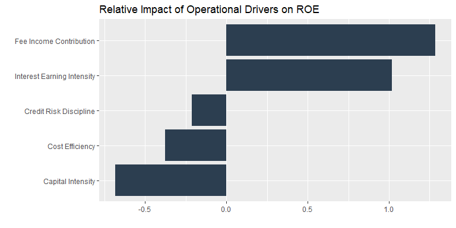

```r
coef_df <- data.frame(
  variable = names(lm.beta(m)$standardized.coefficients)[names(lm.beta(m)$standardized.coefficients) != "(Intercept)"],
  beta = lm.beta(m)$standardized.coefficients[names(lm.beta(m)$standardized.coefficients) != "(Intercept)"]
)
coef_df$variable <- c("Interest Earning Intensity", "Fee Income Contribution", "Cost Efficiency", "Credit Risk Discipline", "Capital Intensity")

print(
  ggplot(coef_df, aes(x = reorder(variable, beta), y = beta)) +
    geom_col(fill = "#2C3E50") +
    coord_flip() +
    labs(
      x = "",
      y = "",
      title = "Relative Impact of Operational Drivers on ROE"
    )
  #+ theme_line()
    #+ theme(
    #axis.text = element_text(size = 12, face="bold"),
    #axis.title = element_text(size = 14),
    #plot.title = element_text(size = 16)
  #)
)
```